# Replication of Faber’s A Quantitative Approach to Tactical Asset Allocation - Asset Class Returns

#### Importing the data into R

Each asset’s class price series has been saved as a CSV. The packages used for performance analysis and backtesting require the data to be xts objects which are created by the following code.

```r
#remove past data
rm(list = ls(envir = globalenv()),envir = globalenv()) #clear Vars from global enviroment
#load required packages
library(PerformanceAnalytics)
library(quantstrat)
#declare symbols
symbols <- c("TBILLS","SP500","EAFE","US10YR","GSCI","NAREIT","CPI")
#use quantmod function to load data as xts objects
getSymbols(symbols,
           src = "csv",
           dir="../Data/CSV files",
           col.names=c("Close"))
```

```
[1] "TBILLS" "SP500"  "EAFE"   "US10YR" "GSCI"   "NAREIT" "CPI"
```

#### Calculating asset class returns and replicating the chart in Faber’s Figure 3

Once the data is loaded i can create one xts object for the prices and calculate each asset class’s returns. The asset class returns are then charted to replicate figure 3 on page 16.

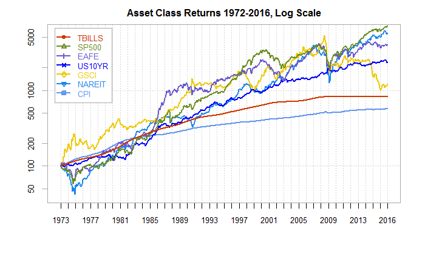

```r
#combine all closing prices into one xts file
AllAssets <- cbind.xts(Cl(TBILLS),
                       Cl(SP500),
                       Cl(EAFE),
                       Cl(US10YR),
                       Cl(GSCI),
                       Cl(NAREIT),
                       Cl(CPI))
SubsetPeriod <- "1972-12-31::2016-12-31"
#subset to required period
AllAssets <- AllAssets[SubsetPeriod]
colnames(AllAssets) <- symbols
#calculate returns and cum returns
AllAssets.ret <- Return.calculate(AllAssets)[-1,]
AllAssets.cumret <- 100*cumprod(1+ ROC(AllAssets, type = "discrete")[-1,])
#chart returns
chart.TimeSeries(AllAssets.cumret[SubsetPeriod],
  main = paste("Asset Class Returns ",substr(SubsetPeriod,1,4),"-",substr(SubsetPeriod,13,16),", Log Scale",sep = ""),
  #lty = "2",
  ylab = "",
  ylog = TRUE,
  ylim = c(40,6100),
  date.format = "%Y",
  major.ticks = "years",
  legend.loc = "topleft",
  colorset = c("orangered3","olivedrab","slateblue","blue","gold2","dodgerblue2","cornflowerblue"), #create own colorset at some point
  minor.ticks =FALSE)
```

The same code can be manipulated to calculate asset class returns focusing on the most recent years

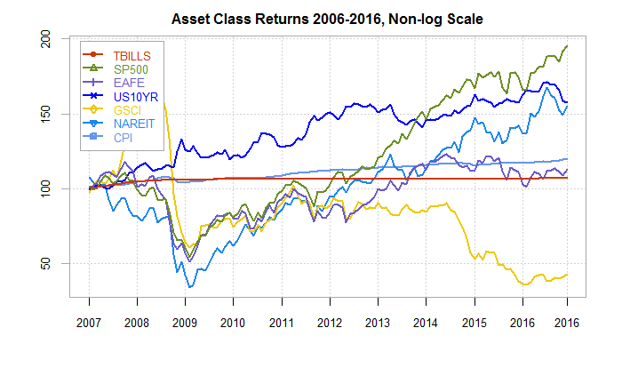

```r
#subset to required period
SubsetPeriod <- "2006-12-31::2016-12-31"
AllAssets2 <- AllAssets[SubsetPeriod]
#calculate returns and cum returns
AllAssets2.ret <- Return.calculate(AllAssets2)[-1,]
AllAssets2.cumret <- 100*cumprod(1+ ROC(AllAssets2, type = "discrete")[-1,])
#chart
chart.TimeSeries(AllAssets2.cumret,
  main = paste("Asset Class Returns ",substr(SubsetPeriod,1,4),"-",substr(SubsetPeriod,13,16),", Non-log Scale",sep = ""),
  ylab = "",
  ylog = FALSE,
  #ylim = c(0,300),
  date.format = "%Y",
  major.ticks = "years",
  legend.loc = "topleft",
  colorset = c("orangered3","olivedrab","slateblue","blue","gold2","dodgerblue2","cornflowerblue"),
  minor.ticks =FALSE)
```

#### Analysing asset class returns, max drawdowns and other performance statistics

Using the package performance analytics, common performance statistics such as CAGR, volatility and sharpe ratios can be calculated. This code replicates Faber’s figure 4 on page 17

```r
#subset to required dates
#Create xts for Returns
SubsetPeriod <- "2006-12-31::2016-12-31"
Returns <- AllAssets.ret[SubsetPeriod]
#calculate statistics and store as "stats"
stats <- rbind(100*Return.annualized(Returns,scale = 12),
               100*StdDev.annualized(Returns,scale = 12),
               SharpeRatio.annualized(Returns,Rf = AllAssets.ret$TBILLS),
               100*maxDrawdown(Returns,scale = 12,invert = FALSE),
               100*c(Return.annualized(Returns$CPI,scale = 12)))
#rename table rows/column names and format
colnames(stats) <- symbols
rownames(stats) <- c("Return","Volatility",paste("Sharpe (",round(stats[1,"TBILLS"],2),"%)", sep = ""),"MaxDD","Inflation CAGR")
stats <- round(stats[,-7],2)
```

Lets print the stats:

```
               TBILLS  SP500   EAFE US10YR   GSCI NAREIT
Return           0.72   7.03   1.52   4.46  -8.71   4.34
Volatility       0.41  15.22  18.58   7.84  23.63  24.10
Sharpe (0.72%)   0.00  -0.10  -0.36  -0.50  -0.68  -0.17
MaxDD            0.00 -50.95 -56.40 -10.21 -80.90 -68.18
Inflation CAGR   1.85   1.85   1.85   1.85   1.85   1.85
```

sharpe ratios dont look right

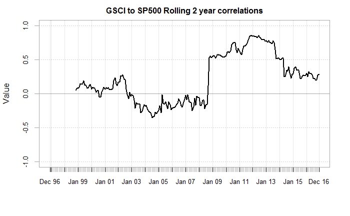

```r
#Create xts for Returns
SubsetPeriod <- "1996-12-31::2016-12-31"
Returns <- AllAssets.ret[SubsetPeriod]
chart.RollingCorrelation(Returns$GSCI,
                         Returns$SP500,
                         width = 24,
                         #legend.loc = "bottomleft"
                         main = "GSCI to SP500 Rolling 2 year correlations"
)
```

now look at GTAA and buy hold (chart and return stats) - with/without commodites 1972-2016 - with/without commodities 2002-2016

#### Managing Risk

Lets chart each asset with its 10 month simple moving average

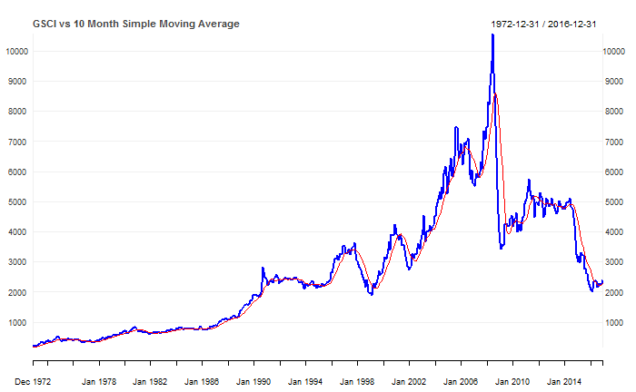

```r
myChart_Theme <- chart_theme() #Create a chart_theme
myChart_Theme$col$line.col <- "blue"
SMAperiod <- 10
SubsetPeriod <- "1972-12-31::2016-12-31"
chart_Series(Cl(GSCI),
  name = paste("GSCI vs 10 Month Simple Moving Average",sep = ""),
  theme=myChart_Theme,
  type = "line",
  subset = SubsetPeriod,
  TA = 'add_SMA(n=SMAperiod, on=1, col="red")'
  )
```

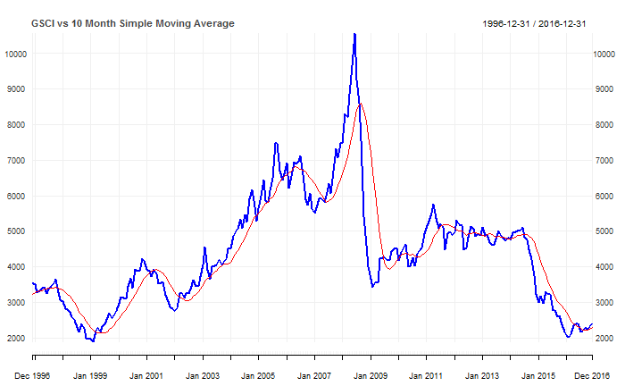

```r
SubsetPeriod <- "1996-12-31::2016-12-31"
chart_Series(Cl(GSCI),
  name = paste("GSCI vs 10 Month Simple Moving Average",sep = ""),
  theme=myChart_Theme,
  type = "line",
  subset = SubsetPeriod,
  TA = 'add_SMA(n=SMAperiod, on=1, col="red")'
  )
```

#### Calculating returns

```r
#also load TBILL YIELDS
getSymbols("TBILLYIELDS",
  src = "csv",
  dir="../Data/CSV files",
  col.names=c("Close"))
```

```
[1] "TBILLYIELDS"
```

```r
library(dplyr)
AllAssets <- cbind.xts(Cl(GSCI),
                       Cl(TBILLYIELDS))
#create dataframe - tidyverse not compatible with xts?
AllAssets.df <- data.frame(date=index(AllAssets), coredata(AllAssets)) #, row.names = index(AllAssets))
#mutate new columns
AllAssets.df  <- mutate(AllAssets.df,
  "10mSMA" = rollmean(GSCI.Close,10,fill = 0,align = "right"),
  "GSCI.ret" = c(0,diff(GSCI.Close)/lag(GSCI.Close)[-1]),
  "Rf.ret" = lag((TBILLYIELDS.Close/100)/12),
  "signal" = lag(ifelse(GSCI.Close>`10mSMA`,1,0)),
  "Timing.ret" = ifelse(signal == 1,GSCI.ret,Rf.ret)
)
rownames(AllAssets.df) <- index(AllAssets)
#detach the packagae dplyr as it isn't compatible with other packages?
detach(package:dplyr)
```

#### Calculating Stats 1972-2016

```r
SubsetPeriod <- "1972-12-31::2016-12-31"
AllAssets <- as.xts(AllAssets.df[,-1])
Returns <- cbind.xts(AllAssets$GSCI.ret, AllAssets$Timing.ret)[SubsetPeriod]
colnames(Returns) <- c("Buy and Hold","Timing")
#for calculating the sharpe ratio later
Rf.ret <- Return.calculate(TBILLS)[-1,]
Rf.ret <- Rf.ret[SubsetPeriod]
#create Cum returns for the chart
CumReturns <- 100*cumprod(1+Returns[-1,])
colnames(CumReturns) <- c("Buy and Hold","Timing")
```

#### Chart the returns

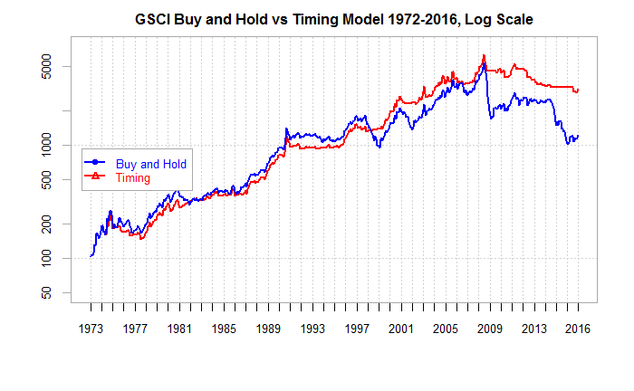

```r
chart.TimeSeries(CumReturns,
  main = paste("GSCI Buy and Hold vs Timing Model ",substr(SubsetPeriod,1,4),"-",substr(SubsetPeriod,13,16),", Log Scale",sep = ""),
  date.format = "%Y",
  colorset = c(4,2),
  ylab = "",
  ylog = TRUE,
  ylim = c(50,7500),
  legend.loc = "left",
  major.ticks = "years",
  minor.ticks = FALSE)
```

#### Drawdown chart

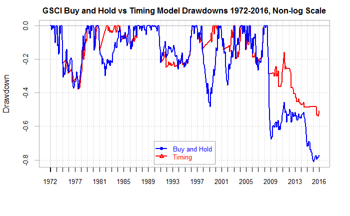

```r
chart.Drawdown(Returns,
  main = paste("GSCI Buy and Hold vs Timing Model Drawdowns ",substr(SubsetPeriod,1,4),"-",substr(SubsetPeriod,13,16),", Non-log Scale",sep = ""),
  date.format = "%Y",
  colorset = c(4,2),
  ylab = "Drawdown",
  legend.loc = "bottom",
  major.ticks = "years",
  minor.ticks = FALSE)
```

```r
stats <- rbind(Return.annualized(Returns,scale = 12)*100,
               StdDev.annualized(Returns,scale = 12)*100,
               SharpeRatio.annualized(Returns,Rf = Rf.ret$TBILLS.Close),
               maxDrawdown(Returns,scale = 12,invert = FALSE)*100,
               c(nrow(subset(Returns, Returns$asset >= 0))/nrow(Returns),nrow(subset(Returns, Returns$Timing.ret >= 0))/nrow(Returns))*100)
colnames(stats) <- c("GSCI Buy and Hold","TIMING")
rownames(stats) <- c("Return","Volatility","Sharpe","MaxDD","% Positive Months")
round(stats,2)
```

```
                  GSCI Buy and Hold TIMING
Return                         6.02   8.31
Volatility                    20.53  16.22
Sharpe                        -0.07   0.04
MaxDD                        -80.90 -53.93
% Positive Months              0.00   0.00
```